# Chemistry_2012_OCG_data_analyses_&_visualization

Elle Horwath

2023-12-07

# OCG 2012 chemistry data analyses and visualization

## Set working directory and load necessary packages for reading in and tidying the data.

```r
if (!require("readr")) {install.packages("readr"); require("readr")}
if (!require("dplyr")) {install.packages("dplyr"); require("dplyr")}
if (!require("tidyr")) {install.packages("tidyr"); require("tidyr")}
if (!require("factoextra")) {install.packages("factoextra"); require("factoextra")}
if (!require("vegan")) {install.packages("vegan"); require("vegan")}
```

```r
if (!require("ggcorrplot")) {install.packages("ggcorrplot"); require("ggcorrplot")}
if (!require("ggpubr")) {install.packages("ggpubr"); require("ggpubr")}
if (!require("devtools")) {install.packages("devtools"); require("devtools")}
if (!require("pairwiseAdonis")) {devtools::install_github("pmartinezarbizu/pairwiseAdonis/pairwiseAdonis"); require("pairwiseAdonis")}
if (!require("ggplot2")) {install.packages("ggplot2"); require("ggplot2")}
```

## Read data in

The data being read is the metadata and the 2012 Orchard Common Garden plant chemistry GC data. The chemistry data has retention time removed consists of compound number, plant ID number and area under the curve (AUC). The metadata and AUC data is just for 2012. Refer to cleaning code for how these dataframes were subsetted.

```r
#read in metadata
mdITS_OCG <- read.csv("data_csv/md_OCG_2012.csv",head=T, check.names = F,stringsAsFactors = T) #96 of 22 variables
```

```r
#read in chemistry data
OCG_AUC_subset <- read.csv("data_csv/OCG_AUC_subset_2012.csv", row.names = 1) #96 of 49 variables
```

## Begin analysis

### Correlation plots

Since PCAs can only be run on numeric data, always check for NAs in the data

```r
 #only works with numeric data
colSums(is.na(OCG_AUC_subset)) #checking for null values since pca wont run with NAs. Should have all zeroes for each column which indictes there are no NA values
```

```
## C002 C003 C006 C007 C008 C010 C012 C013 C014 C016 C018 C019 C020 C021 C022 C025
##    0    0    0    0    0    0    0    0    0    0    0    0    0    0    0    0
## C026 C028 C029 C030 C031 C032 C033 C034 C035 C037 C038 C039 C040 C041 C042 C043
##    0    0    0    0    0    0    0    0    0    0    0    0    0    0    0    0
## C044 C045 C046 C048 C049 C050 C051 C052 C053 C054 C055 C057 C063 C065 C067 C068
##    0    0    0    0    0    0    0    0    0    0    0    0    0    0    0    0
## C069
##    0
```

Now the data needs to be normalized using the scale function in base r

```r
data_normalized <- scale(OCG_AUC_subset) #so this will center the data.... able to code this instead of using excel to do this
head(data_normalized) #looks good
```

```
##            C002        C003       C006       C007       C008       C010
## 300 -0.15302488 -0.14081917 -0.6920371 -0.4609936 -0.2462836 -0.4710326
## 388 -0.73920786  1.61347885  2.0970308  2.5923521  2.5954838 -0.2576214
## 47   0.07730635 -1.20117375 -0.6919331 -0.4607318 -0.2459293 -0.4902416
## 311 -0.27190400  0.05088841  1.3788532 -0.4604290 -0.2455193 -0.8124404
## 48  -0.73935871 -0.61629105 -0.6921925 -0.4613850 -0.2468135 -0.2710315
## 130  0.09797243 -0.63098942 -0.6918699 -0.4605726 -0.2457138 -0.4197558
##           C012       C013       C014        C016       C018       C019
## 300 -0.5349099 -0.8663140 -0.1628528  0.04949626 -0.4316531 -0.3059841
## 388 -0.5347134 -0.7712596 -0.3505234 -0.72995199 -0.4299137  1.7531186
## 47   0.5571820  2.3803523 -0.3506634 -0.59398983  2.7868038 -0.6717812
## 311 -0.5347668 -1.0402731 -0.3505809 -0.98092285 -0.4303866 -0.2213317
## 48   0.5419883  0.7037179 -0.3508413  0.28689017 -0.4325311 -0.6719718
## 130 -0.5348032 -1.0402903 -0.3506200 -0.37609261 -0.4307088 -0.6717347
##           C020       C021       C022        C025        C026       C028
```

[output cut: 48 more lines]

Now we will make a correlation plot showing which compounds may be positively or negatively correlated with others.

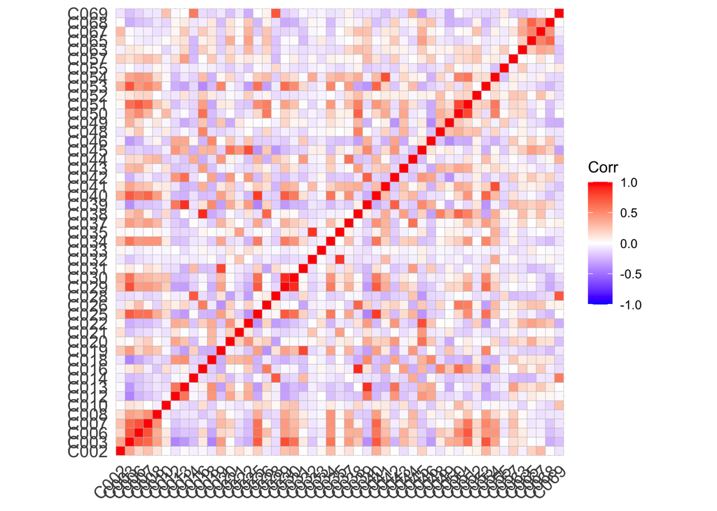

```r
corr_matrix <- cor(data_normalized)
ggcorrplot(corr_matrix)
```

### PCAs #### PCA by compound

```r
data.pca <- princomp(corr_matrix)
summary(data.pca)
```

```
## Importance of components:
##                           Comp.1    Comp.2    Comp.3     Comp.4    Comp.5
## Standard deviation     1.2867207 0.7661677 0.5987972 0.40722522 0.3429962
## Proportion of Variance 0.4854755 0.1721260 0.1051376 0.04862595 0.0344967
## Cumulative Proportion  0.4854755 0.6576015 0.7627392 0.81136513 0.8458618
##                           Comp.6     Comp.7    Comp.8     Comp.9    Comp.10
## Standard deviation     0.3147677 0.28560212 0.2603722 0.20031084 0.18713401
## Proportion of Variance 0.0290522 0.02391782 0.0198787 0.01176543 0.01026843
## Cumulative Proportion  0.8749140 0.89883184 0.9187105 0.93047597 0.94074440
##                            Comp.11     Comp.12     Comp.13     Comp.14
## Standard deviation     0.169033910 0.162537053 0.150966856 0.133549400
## Proportion of Variance 0.008378118 0.007746465 0.006682854 0.005229771
## Cumulative Proportion  0.949122518 0.956868982 0.963551837 0.968781608
##                            Comp.15     Comp.16     Comp.17     Comp.18
## Standard deviation     0.130662105 0.121037960 0.102218880 0.099141168
## Proportion of Variance 0.005006083 0.004295779 0.003063804 0.002882085
## Cumulative Proportion  0.973787691 0.978083470 0.981147275 0.984029360
##                            Comp.19     Comp.20     Comp.21     Comp.22
## Standard deviation     0.096056312 0.089638389 0.085767187 0.072794971
## Proportion of Variance 0.002705519 0.002356063 0.002156955 0.001553823
## Cumulative Proportion  0.986734879 0.989090942 0.991247897 0.992801720
##                            Comp.23     Comp.24      Comp.25      Comp.26
## Standard deviation     0.064194551 0.062380867 0.0561976036 0.0497659068
## Proportion of Variance 0.001208357 0.001141042 0.0009260499 0.0007262107
## Cumulative Proportion  0.994010077 0.995151119 0.9960771684 0.9968033791
##                             Comp.27      Comp.28     Comp.29      Comp.30
## Standard deviation     0.0426560815 0.0409615986 0.037790144 0.0325804156
## Proportion of Variance 0.0005335323 0.0004919858 0.000418751 0.0003112519
## Cumulative Proportion  0.9973369114 0.9978288972 0.998247648 0.9985589001
##                             Comp.31      Comp.32      Comp.33      Comp.34
## Standard deviation     0.0315866053 0.0289473712 0.0255418485 0.0237614433
## Proportion of Variance 0.0002925531 0.0002457067 0.0001912949 0.0001655558
## Cumulative Proportion  0.9988514532 0.9990971599 0.9992884548 0.9994540106
##                             Comp.35      Comp.36      Comp.37      Comp.38
## Standard deviation     0.0209964435 0.0190574888 0.0161888522 1.391717e-02
## Proportion of Variance 0.0001292678 0.0001064952 0.0000768477 5.679379e-05
## Cumulative Proportion  0.9995832784 0.9996897736 0.9997666213 9.998234e-01
##                             Comp.39      Comp.40      Comp.41      Comp.42
## Standard deviation     1.270313e-02 1.178459e-02 9.364930e-03 8.380603e-03
## Proportion of Variance 4.731732e-05 4.072188e-05 2.571626e-05 2.059441e-05
## Cumulative Proportion  9.998707e-01 9.999115e-01 9.999372e-01 9.999578e-01
##                             Comp.43      Comp.44      Comp.45      Comp.46
## Standard deviation     6.594690e-03 6.427652e-03 5.120747e-03 3.956987e-03
## Proportion of Variance 1.275227e-05 1.211444e-05 7.688920e-06 4.591220e-06
## Cumulative Proportion  9.999705e-01 9.999826e-01 9.999903e-01 9.999949e-01
##                             Comp.47      Comp.48 Comp.49
## Standard deviation     3.330461e-03 2.502112e-03       0
## Proportion of Variance 3.252427e-06 1.835745e-06       0
## Cumulative Proportion  9.999982e-01 1.000000e+00       1
```

```r
data.pca$loadings[, 1:2]
```

```
##             Comp.1       Comp.2
## C002  0.0655170659  0.018035309
## C003  0.2707489245 -0.097292839
## C006  0.2066357196 -0.151191206
## C007  0.2002147937 -0.028857538
## C008  0.1433122689  0.067039488
## C010  0.0506001642 -0.077548579
## C012 -0.1866891618  0.039003728
## C013 -0.2060016607 -0.026869692
## C014 -0.0003328139  0.191003480
## C016 -0.0309778710 -0.346272959
## C018 -0.1866984873  0.066397745
## C019  0.1794073603  0.184154088
## C020 -0.0819849172 -0.044478738
## C021 -0.0752233065  0.025296282
## C022 -0.1907481116 -0.102450538
## C025  0.2557097136  0.061748397
## C026 -0.0466507014 -0.279335667
## C028  0.0170800646  0.145261371
## C029  0.2448445363 -0.012793382
## C030  0.1906068875 -0.001807262
## C031  0.0905480732  0.185719785
## C032 -0.0278864956 -0.016896547
## C033 -0.0122469623  0.015107609
## C034  0.2113459098  0.012700676
## C035  0.0203445831 -0.034891822
## C037  0.1453033680  0.041481569
## C038  0.0158836121 -0.357359518
## C039 -0.2258880243 -0.059202572
## C040  0.2374707195  0.040235709
## C041  0.1145747926 -0.186347509
## C042 -0.1809729869 -0.013370230
## C043  0.0933124753 -0.192907400
## C044  0.1100193812  0.197728219
## C045 -0.1791803938 -0.128032164
## C046 -0.1364733656  0.151520964
## C048  0.0164616184 -0.220802113
## C049  0.0893675955 -0.113497651
## C050  0.0927353690 -0.294077804
## C051  0.1744757979 -0.228389079
## C052 -0.0179064776 -0.115329359
## C053  0.2341780293  0.115274969
## C054  0.1168384561 -0.201192287
## C055  0.0044949258  0.003758788
## C057 -0.0249949866 -0.034620447
## C063 -0.0555499710 -0.135385471
## C065 -0.1005046666 -0.064346722
## C067 -0.1009734583 -0.105793306
## C068 -0.1332595261  0.009145625
## C069 -0.0043790300  0.137949103
```

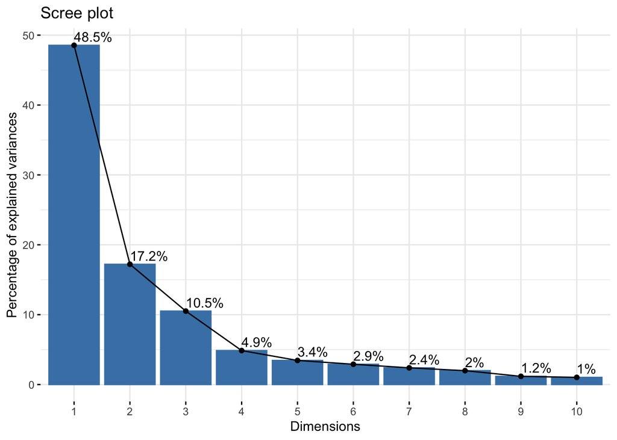

```r
fviz_eig(data.pca, addlabels = TRUE) #scree plot is used to visualize the importance of each principal component and can be used to determine the number of principal components to retain.
```

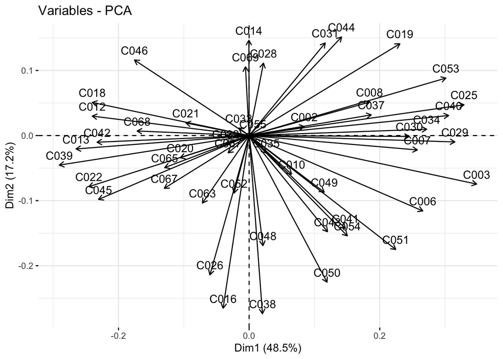

```r
#With the biplot, it is possible to visualize the similarities and dissimilarities between the samples, and further shows the impact of each attribute on each of the principal components.

# Graph of the variables
fviz_pca_var(data.pca, col.var = "black")
```

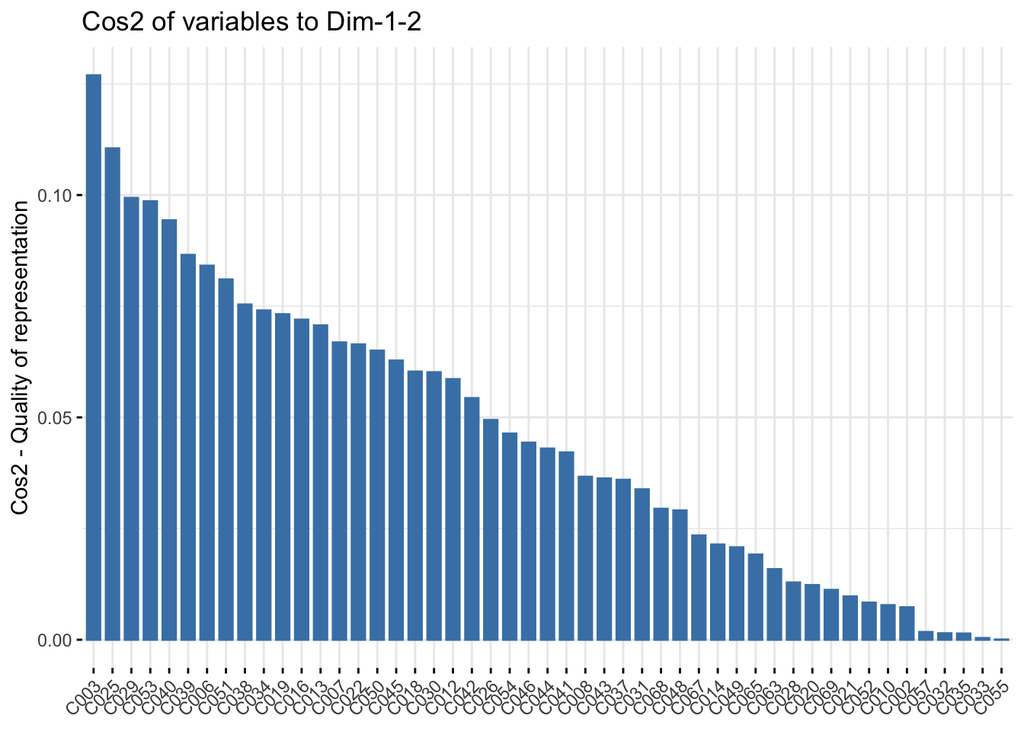

```r
#Contribution of each variable
fviz_cos2(data.pca, choice = "var", axes = 1:2)
```

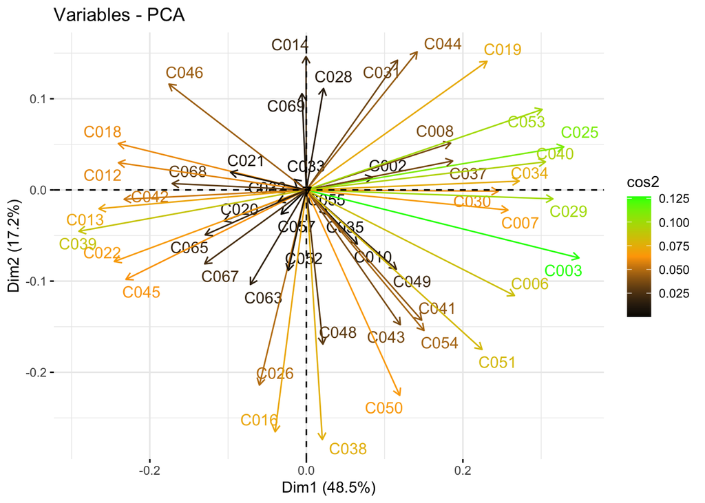

```r
#Biplot combined with cos2
fviz_pca_var(data.pca, col.var = "cos2",
             gradient.cols = c("black", "orange", "green"),
             repel = TRUE)
```

#### PCA by Plant ID First the AUC data needs to be transposed in order to plot the PCA

```r
#transpose the data first to put plant ID as columns and compound as row
OCG_cen_subset.t <- t(OCG_AUC_subset) # transpose rows and columns
```

Then the data will be check for NAs and normalized.

```r
#only works with numeric data
colSums(is.na(OCG_cen_subset.t)) #checking for null values since pca wont run with NAs
```

```
## 300 388  47 311  48 130 217 401 121 458 265 126 293 132  43 177 358 131  72 261
##   0   0   0   0   0   0   0   0   0   0   0   0   0   0   0   0   0   0   0   0
## 224 379 138 269 429 273 230 120 377 320 111 209 185 266 456 102 193  71 347 262
##   0   0   0   0   0   0   0   0   0   0   0   0   0   0   0   0   0   0   0   0
##  63 101 357 233 235 372  70  93 374 366 417  23 164 213 205 150 220 290 122 380
##   0   0   0   0   0   0   0   0   0   0   0   0   0   0   0   0   0   0   0   0
## 248 181 413  15 212 403 245 314 186 333  25 294  20 409 421 281   6 296  84 157
##   0   0   0   0   0   0   0   0   0   0   0   0   0   0   0   0   0   0   0   0
## 189 271 216 304 195  10 268 282  64 287 418 356 436 378 135 236
##   0   0   0   0   0   0   0   0   0   0   0   0   0   0   0   0
```

```r
data_normalized.ID <- scale(OCG_cen_subset.t) #so this will center the data.... able to code this instead of using excel to do this
head(data_normalized.ID) #looks good
```

```
##             300         388          47        311         48        130
## C002  0.6245526 -0.37334965  0.06221207  0.7939730 -0.3910772  1.8894166
## C003  2.6609903  1.75319336 -0.30355523  4.6483635  0.3654636  2.0158317
## C006 -0.5093186  0.07034676 -0.30355523  1.3367475 -0.3910772 -0.5046195
## C007 -0.5093186 -0.18047343 -0.30355523 -0.4328794 -0.3910772 -0.5046195
## C008 -0.5093186 -0.24074851 -0.30355523 -0.4328794 -0.3910772 -0.5046195
## C010  0.2215288 -0.07328428 -0.14382380 -0.4328794  0.1103014  0.7380721
##             217        401         121        458        265        126
## C002  1.4296420  1.0883475  0.14332710 -0.3389274  0.2257228 -0.3295664
## C003  1.6239149 -0.3592054  0.19296368 -0.3389274 -0.3662034 -0.3295664
## C006 -0.4683101 -0.3592054 -0.30186329 -0.3389274 -0.3662034 -0.3295664
## C007 -0.4683101 -0.3592054 -0.30186329 -0.3389274 -0.3662034 -0.3295664
## C008 -0.4683101 -0.3592054 -0.30186329 -0.3389274 -0.3662034 -0.3295664
## C010  3.0127922  0.1606149 -0.08000835 -0.1021505  0.1017462  0.1307536
##             293        132         43        177          358        131
## C002  0.3637996 -0.3836173  0.2167818 -0.0340674  0.186516237  1.1725838
## C003  0.5534441  0.3188061  0.4761408 -0.3693768 -0.348209994  1.8301898
## C006 -0.4746689 -0.3836173 -0.4304142 -0.3693768 -0.348209994 -0.5213583
## C007 -0.4746689 -0.3836173 -0.4304142 -0.3693768 -0.348209994 -0.5213583
## C008 -0.4746689 -0.3836173 -0.4304142 -0.3693768 -0.348209994 -0.5213583
## C010  0.5354636  0.4415360  0.6483649  0.2441015 -0.007967768  0.4813187
##              72        261        224         379         138        269
## C002  0.7316082  0.9789889  0.4239380 -0.01180471 -0.06538281  3.7586912
## C003 -0.4098243  0.3385572  0.5001222  0.62718195  0.28709341  2.4922200
## C006 -0.4098243 -0.5724493 -0.4700195 -0.16680787 -0.47732526  0.1081609
## C007 -0.4098243 -0.5724493 -0.4700195 -0.38588081 -0.47732526 -0.2185639
## C008 -0.4098243 -0.5724493 -0.4700195 -0.38588081 -0.47732526 -0.4347990
## C010 -0.2078212 -0.1543417 -0.4700195  0.31571898 -0.14179094  0.3791860
##             429         273        230        120         377        320
## C002 -0.4338781 -0.15232798 -0.4864673  0.2752594  0.02988272 -0.2794899
## C003  2.8832417  3.68467675  4.3974782 -0.3947270 -0.32782002 -0.2794899
## C006 -0.4338781  0.28774299 -0.4864673 -0.3947270 -0.32782002 -0.2794899
## C007 -0.4338781 -0.09596222 -0.4864673 -0.3947270 -0.32782002 -0.2794899
## C008 -0.4338781 -0.23622483 -0.4864673 -0.3947270 -0.32782002 -0.2794899
## C010  0.2914493  0.25155847  0.1774625  0.1725804  0.08248745 -0.2794899
##            111         209        185        266        456         102
## C002 -0.281992 -0.03129565  0.5962903 -0.2675287 -0.2318414 -0.00206543
## C003 -0.281992  0.64405588  1.1855165  0.2831076 -0.2318414 -0.30899636
## C006 -0.281992 -0.42852756 -0.5043763 -0.3790689 -0.2318414 -0.30899636
## C007 -0.281992 -0.42852756 -0.5043763 -0.3790689 -0.2318414 -0.30899636
```

[output cut: 57 more lines]

```
## C010  0.8616273  1.17006158 -0.3911817  0.4281974 -0.5019190  0.80776899
##             195          10         268        282          64         287
## C002  2.4371424 -0.10271855 -0.21130920  0.1324188  2.39055837 -0.31216219
## C003  3.3160969  1.65503422  1.18715177  1.0786007  1.28879350  0.78458277
## C006 -0.4965255 -0.47859798 -0.09064655 -0.1554557 -0.48751873 -0.05211103
## C007 -0.4965255 -0.47859798 -0.29441296 -0.4686689 -0.48751873 -0.24279758
## C008 -0.4965255 -0.47859798 -0.45634382 -0.4686689 -0.48751873 -0.39872099
## C010  0.2903300 -0.02914027  0.01452641 -0.1386217 -0.05380726 -0.04947354
##              418         356          436         378         135        236
## C002 -0.22750106 -0.11117700 -0.345680325  0.01046281 -0.39147518 -0.3945091
## C003  1.08910711  0.84093458  0.963634822  0.86555342  0.45524392  0.9783130
## C006 -0.04801243 -0.08542807 -0.003192757 -0.41145241 -0.39147518  0.1410620
## C007 -0.41827174 -0.40656735 -0.418146480 -0.41145241 -0.39147518 -0.1735555
## C008 -0.41827174 -0.40656735 -0.418146480 -0.41145241 -0.39147518 -0.3945091
## C010  0.82262841  0.17781418  0.192692831  0.16625119  0.09041502  0.3029070
```

This data can now be put as a correlation matrix. Plotting as a correlation plot is not pretty since the sample size is relatively large for these plots.

```r
corr_matrix.ID <- cor(data_normalized.ID)
```

```r
data.pca_ID <- princomp(corr_matrix.ID)
summary(data.pca_ID)
```

```
## Importance of components:
##                           Comp.1    Comp.2     Comp.3     Comp.4     Comp.5
## Standard deviation     2.1899924 0.9642502 0.74534181 0.53257373 0.40398179
## Proportion of Variance 0.6997085 0.1356474 0.08104811 0.04138009 0.02380979
## Cumulative Proportion  0.6997085 0.8353559 0.91640398 0.95778407 0.98159385
##                             Comp.6      Comp.7      Comp.8      Comp.9
## Standard deviation     0.198064668 0.178712069 0.138937933 0.118795154
## Proportion of Variance 0.005723293 0.004659504 0.002816266 0.002058872
## Cumulative Proportion  0.987317145 0.991976650 0.994792915 0.996851787
##                           Comp.10      Comp.11      Comp.12      Comp.13
## Standard deviation     0.08539819 0.0750378335 0.0564588866 0.0444821291
## Proportion of Variance 0.00106397 0.0008214715 0.0004650467 0.0002886709
## Cumulative Proportion  0.99791576 0.9987372284 0.9992022751 0.9994909460
##                             Comp.14      Comp.15      Comp.16      Comp.17
## Standard deviation     0.0371538538 0.0266169886 2.312072e-02 1.593643e-02
## Proportion of Variance 0.0002013908 0.0001033593 7.798925e-05 3.705222e-05
## Cumulative Proportion  0.9996923368 0.9997956962 9.998737e-01 9.999107e-01
##                             Comp.18      Comp.19      Comp.20      Comp.21
## Standard deviation     0.0141549653 1.208959e-02 9.729911e-03 8.233254e-03
## Proportion of Variance 0.0000292314 2.132332e-05 1.381178e-05 9.889515e-06
## Cumulative Proportion  0.9999399690 9.999613e-01 9.999751e-01 9.999850e-01
##                             Comp.22      Comp.23      Comp.24      Comp.25
## Standard deviation     6.889771e-03 4.242074e-03 3.358461e-03 3.047337e-03
## Proportion of Variance 6.925347e-06 2.625357e-06 1.645555e-06 1.354793e-06
## Cumulative Proportion  9.999919e-01 9.999945e-01 9.999962e-01 9.999975e-01
##                             Comp.26      Comp.27      Comp.28      Comp.29
## Standard deviation     2.317160e-03 1.848399e-03 1.414953e-03 1.173365e-03
## Proportion of Variance 7.833285e-07 4.984520e-07 2.920894e-07 2.008623e-07
## Cumulative Proportion  9.999983e-01 9.999988e-01 9.999991e-01 9.999993e-01
##                             Comp.30      Comp.31      Comp.32      Comp.33
## Standard deviation     1.106432e-03 9.044786e-04 7.486426e-04 7.280577e-04
## Proportion of Variance 1.786001e-07 1.193517e-07 8.176754e-08 7.733277e-08
## Cumulative Proportion  9.999995e-01 9.999996e-01 9.999997e-01 9.999998e-01
##                             Comp.34      Comp.35      Comp.36      Comp.37
## Standard deviation     6.168255e-04 5.221729e-04 5.006447e-04 4.170129e-04
## Proportion of Variance 5.550813e-08 3.977962e-08 3.656716e-08 2.537061e-08
## Cumulative Proportion  9.999998e-01 9.999999e-01 9.999999e-01 9.999999e-01
##                             Comp.38      Comp.39      Comp.40      Comp.41
## Standard deviation     3.685983e-04 3.012107e-04 2.914729e-04 2.095124e-04
## Proportion of Variance 1.982160e-08 1.323649e-08 1.239448e-08 6.404001e-09
```

[output cut: 34 more lines]

```
## Standard deviation           0       0       0       0       0       0       0
## Proportion of Variance       0       0       0       0       0       0       0
## Cumulative Proportion        1       1       1       1       1       1       1
##                        Comp.81 Comp.82 Comp.83 Comp.84 Comp.85 Comp.86 Comp.87
## Standard deviation           0       0       0       0       0       0       0
## Proportion of Variance       0       0       0       0       0       0       0
## Cumulative Proportion        1       1       1       1       1       1       1
##                        Comp.88 Comp.89 Comp.90 Comp.91 Comp.92 Comp.93 Comp.94
## Standard deviation           0       0       0       0       0       0       0
## Proportion of Variance       0       0       0       0       0       0       0
## Cumulative Proportion        1       1       1       1       1       1       1
##                        Comp.95 Comp.96
## Standard deviation           0       0
## Proportion of Variance       0       0
## Cumulative Proportion        1       1
```

```r
data.pca_ID$loadings[, 1:2] #need to talk about this
```

```
##           Comp.1       Comp.2
## 300  0.054587472  0.203947252
## 388  0.121230427  0.031483000
## 47  -0.148411529 -0.002285016
## 311  0.031137305  0.123897459
## 48  -0.143472753  0.053068377
## 130  0.049964613  0.201083111
## 217 -0.076567419  0.113448810
## 401 -0.141555383  0.054515241
## 121 -0.005063068  0.039882990
## 458 -0.129544123  0.027846510
## 265 -0.141439273  0.031292353
## 126 -0.153456300  0.009787903
## 293 -0.089802880  0.069447218
## 132 -0.141627624  0.040619199
```

[output cut: 82 more lines]

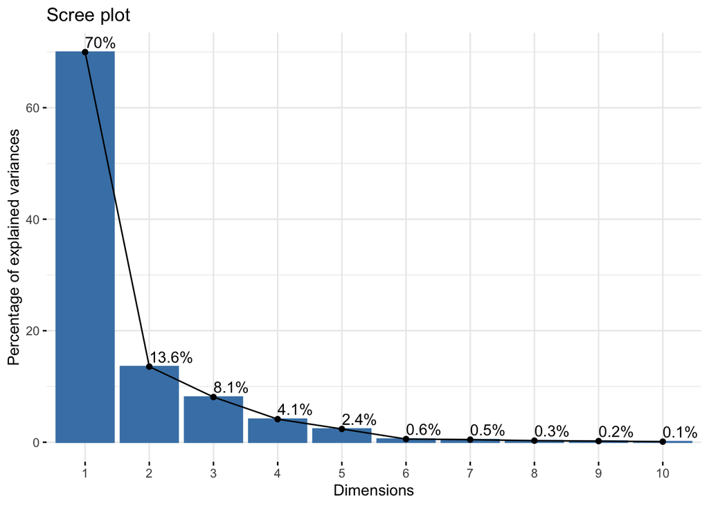

```r
fviz_eig(data.pca_ID, addlabels = TRUE) #scree plot
```

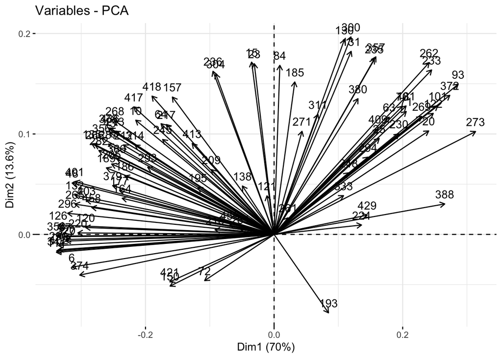

```r
# Graph of the variables
fviz_pca_var(data.pca_ID, col.var = "black") #pca
```

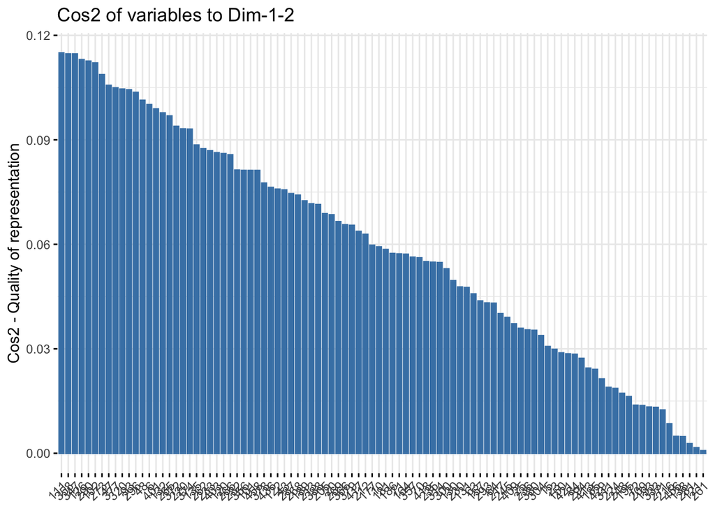

```r
#Contribution of each variable
fviz_cos2(data.pca_ID, choice = "var", axes = 1:2)
```

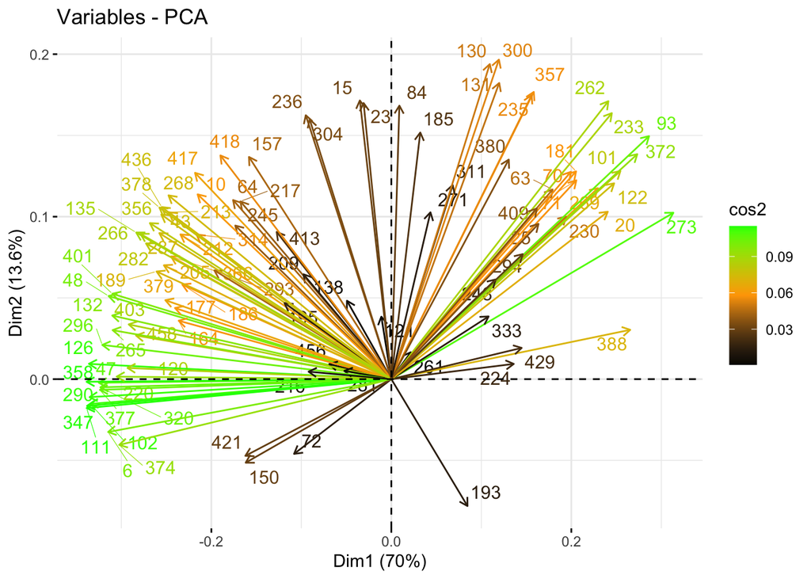

```r
#Biplot combined with cos2
fviz_pca_var(data.pca_ID, col.var = "cos2",
             gradient.cols = c("black", "orange", "green"),
             repel = TRUE)
```

### NMDS plots with chemistry data ##### NMDS by Compound Make the variables factors

```r
mdITS_OCG$Subspecies <- as.factor(mdITS_OCG$Subspecies)
mdITS_OCG$Subsp_ploidy <- as.factor(mdITS_OCG$Subsp_ploidy)
mdITS_OCG$Year <- as.factor(mdITS_OCG$Year)
mdITS_OCG$Ploidy <- as.factor(mdITS_OCG$Ploidy)
```

The AUC dataframe then has to be made into a matrix

```r
#turn abundance data frame into a matrix
m_OCG_AUC_subset = as.matrix(OCG_AUC_subset)
```

Now set the seed and run an nmds on the matix. This can be aved so it doesnt have to be rerun once a solution is reached.

```r
set.seed(365)
#OCG_AUC_subset.nmds <- metaMDS(t(m_OCG_AUC_subset), trymax=500) #solution reached.
#save(OCG_AUC_subset.nmds, file = "nmds/OCG_AUC_subset.nmds.rda")
load("nmds/OCG_AUC_subset.nmds.rda")
```

Plot using ordiplot. This is sufficient since the nmds for compound is not what I am particularly interested in. The plant ID nmds will be more in depth below.

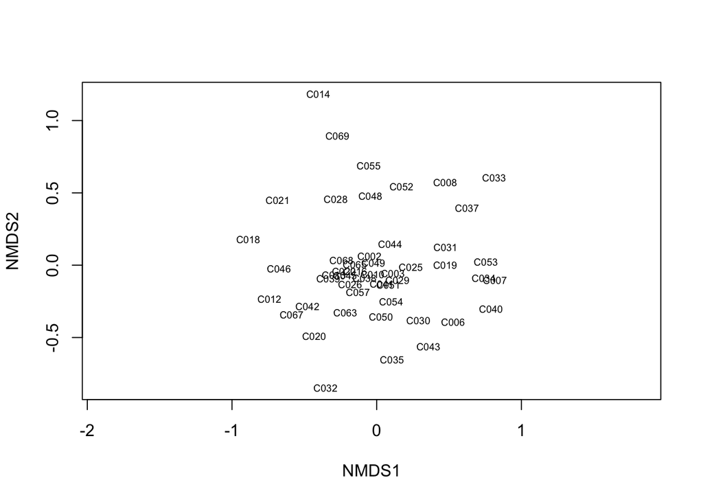

```r
ordiplot(OCG_AUC_subset.nmds, type = "t",display = "sites",cex = .6)
```

#### NMDS by Plant ID The AUC data will now be transposed and put as a matrix for the nmds.

```r
OCG_AUC_subset.t <- t(OCG_AUC_subset)

m_OCG_AUC_subset.t = as.matrix(OCG_AUC_subset.t)
```

Set the seed and run the nmds. It can be saved so it won’t need to be run after a solution has been reached.

```r
set.seed(6)
#Plant_ID_OCG_AUC.nmds <- metaMDS(t(m_OCG_AUC_subset.t), trymax=500) #solution reached.
#save(Plant_ID_OCG_AUC.nmds, file = "nmds/Plant_ID_OCG_AUC.nmds.rda")
load("nmds/Plant_ID_OCG_AUC.nmds.rda")
```

Plot using ordiplot.

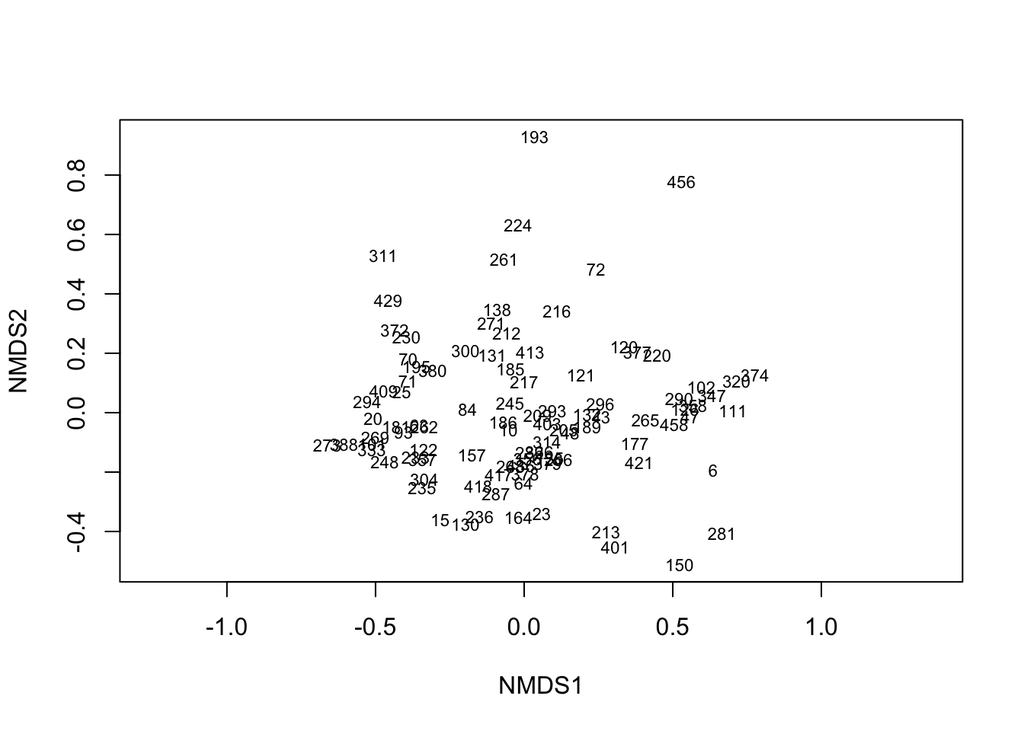

```r
ordiplot(Plant_ID_OCG_AUC.nmds, type = "t",display = "sites",cex = .7)
```

The below NMDS plots will show clustering based on the variable given ##### NMDS Plant ID - Ploidy

```r
mdITS_OCG$Ploidy<- droplevels(mdITS_OCG$Ploidy)
levels(mdITS_OCG$Ploidy) #Always smart to check levels before plotting. If there are too many or too few levels, the nmds plots wont line up with the ordispider function.
```

```
## [1] "2n" "4n"
```

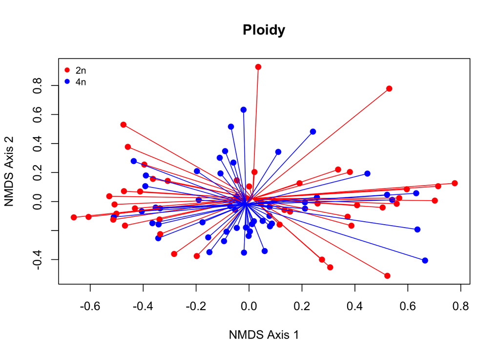

```r
plot(Plant_ID_OCG_AUC.nmds$points[,1:2], xlab="NMDS Axis 1", ylab="NMDS Axis 2",
     main="Ploidy",
     col= c("red","blue")[mdITS_OCG$Ploidy],
     pch=c(19))
legend("topleft",
       legend=c("2n","4n"),
       col= c("red","blue"),
       pch=19,
       cex=0.8,
       bty = "n")
ordispider(Plant_ID_OCG_AUC.nmds,groups = mdITS_OCG$Ploidy, show.groups = "2n", col = "red")
ordispider(Plant_ID_OCG_AUC.nmds,groups = mdITS_OCG$Ploidy, show.groups = "4n", col = "blue")
```

#### PERMANOVAS for ploidy

```r
OCG_AUC_ploidy <- adonis2(OCG_AUC_subset ~ mdITS_OCG$Ploidy,by="margin") # Bray-Curtis is the default metric
OCG_AUC_ploidy #ploidy significant
```

```
## Permutation test for adonis under reduced model
## Marginal effects of terms
## Permutation: free
## Number of permutations: 999
##
## adonis2(formula = OCG_AUC_subset ~ mdITS_OCG$Ploidy, by = "margin")
##                  Df SumOfSqs      R2      F Pr(>F)
## mdITS_OCG$Ploidy  1   0.4058 0.02491 2.4016   0.03 *
## Residual         94  15.8842 0.97509
## Total            95  16.2900 1.00000
## ---
## Signif. codes:  0 '***' 0.001 '**' 0.01 '*' 0.05 '.' 0.1 ' ' 1
```